# Index Computational Musicology

Isa Alders

2/9/2021

**DO NOT SHOW THIS IN CLASS**

Growing up I’ve always listened to a lot of music at home. My parents are all big on music, especially my mom and my stepdad. Before the covid pandemic they used to go to concerts at least twice a month, and listen to music all day (this they still do). We as a family have gone to multiple concerts together, and always send in our lists for the top 2000 (an anual radio show each year where the listeners can vote for). Me and my mom have noticed that our lists always have many of the same songs on there. Now I actually have the opportunity, I would like to research the similarities in the music we listen to. I would like to do that by comparing my “Your Top Songs 2020” en “Your Top Songs 2019” to the ones of my parents account. These are lists Spotify creates for you. They contain the 100 songs you listened to most that specific year.

There are a few things that could influence the outcome: (1) my mom and stepdad share a Spotify account, and since my stepdad is a little more into really old Rock than I am I don’t know how much this would influence their list, (2) I’m ashamed to admit it but since the beginning of covid I’ve been watching a little to many TikToks, and have been listening to a lot of TikTok music. This is why I also included my 2019 list and maybe my 2018 list. My music taste back then hadn’t been poisoned by TikTok :-).

I expect the lists to show similarities in instrumentalness, loudness, speechiness, tempo and type. Typical songs in my lists that I expect are similar to the list of my mom are Under The Influence by James Morrison, The Chain by Fleetwood Mac, Let Me Live by Rudimental and Everlasting Light by The Black Keys. Songs that I think are atypical are Yummy by Justin Bieber, Goosebumps by Travis Scott, Love Me Like You by Little Mix.

```r
library(tidyverse)
library(spotifyr)
spotifyr::get_spotify_access_token()
```

```
## [1] "BQB--eGfgc9u_ZZ0S1knaRoUW3rvxjlQFaCt5vz1xENXeA8qbvIQELz8ZktWm7VY0nyKtVdielnQjn-0smo"
```

```r
library(dplyr)
```

```r
isa <- get_playlist_audio_features("", "2JhcfrBpNKGKB5vut5PIY1")
mh <- get_playlist_audio_features("", "5DCCNsnEiJzi3uzhkMNdkG")


all_music <-
  bind_rows(
    isa %>% mutate(category = "Isa"),
    mh %>% mutate(category = "MH")
  )
```

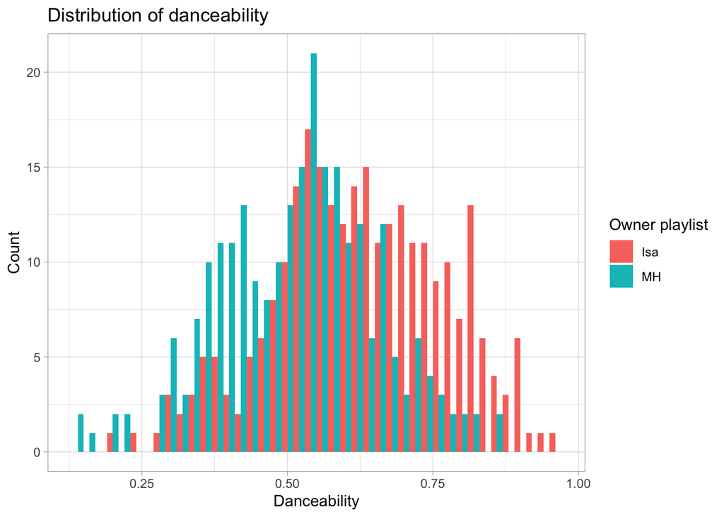

In the plot above we can see a histogram for the danceability. We can see that the less danceable songs are mostly present in the playlist of my parents (MH), and the more danceable songs can be found in my playlist.

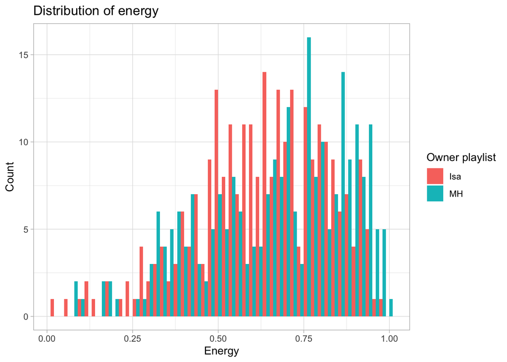

In the plot above we can see a histogram for the energy We can see that in general, all songs are relatively high in energy. The playlist of my parents (MH) contains the most high energy songs. My playlist contains more medium to high level energy songs.

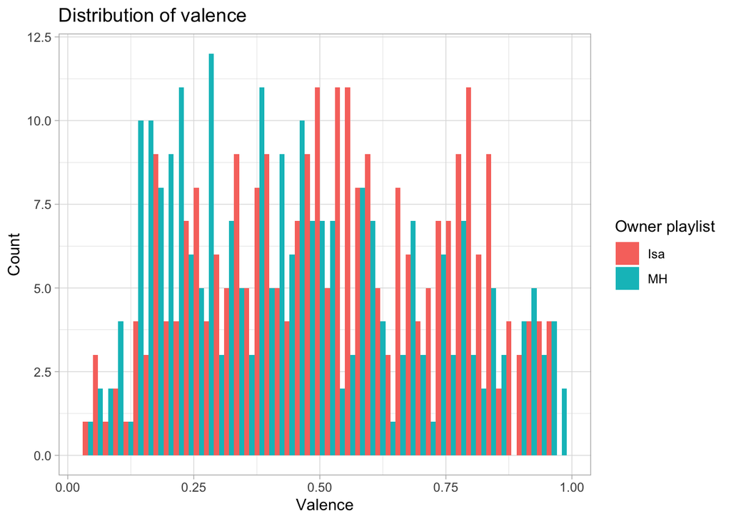

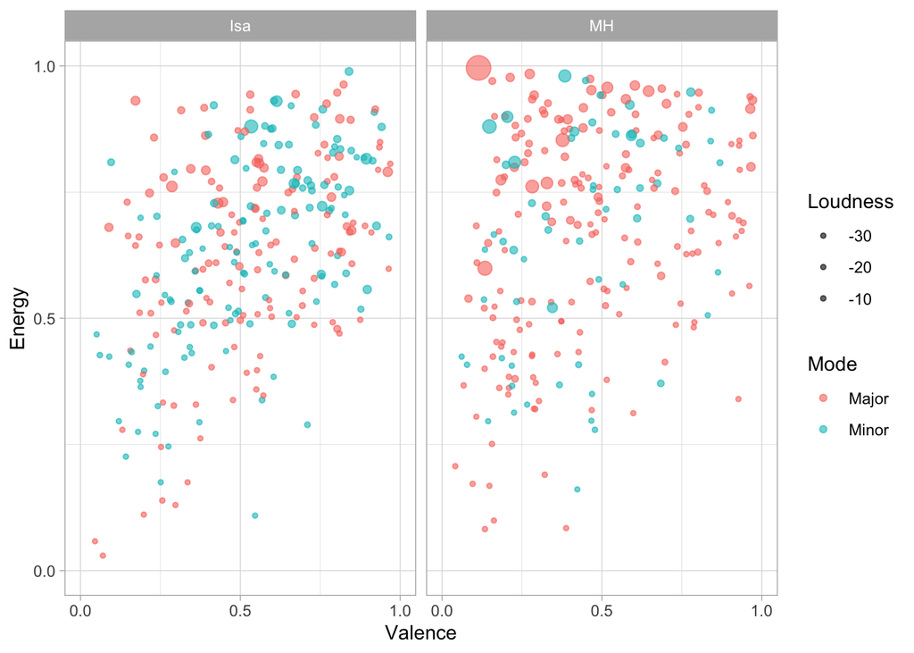

In these plots you can see the energy plotted against the valence. Color is used to distinguish the mode, major and minor. The size of the dot shows the loudness of the specific song. The two plots are seperated to show the plot of my own playlist on the left, and the music of my parents playlist on the right.